# Reproducible Research: Peer Assessment 1

yhyim

2017-03-07

### 1. Loading and preprocessing the data

```r
dat <- read.csv("activity.csv")
str(dat)
```

```
## 'data.frame':    17568 obs. of  3 variables:
##  $ steps   : int  NA NA NA NA NA NA NA NA NA NA ...
##  $ date    : Factor w/ 61 levels "2012-10-01","2012-10-02",..: 1 1 1 1 1 1 1 1 1 1 ...
##  $ interval: int  0 5 10 15 20 25 30 35 40 45 ...
```

To make a histogram of the total number of steps taken each day, aggregating the data by date and getting sum of steps.

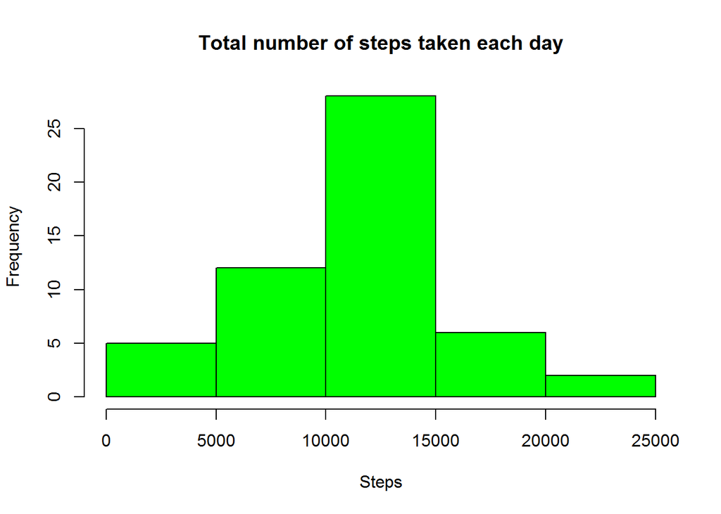

```r
sumOfSteps <- aggregate(steps ~ date, dat, sum)

hist(sumOfSteps$steps, main = "Total number of steps taken each day", xlab = "Steps", col="green")
```

```r
mean(dat$steps, na.rm = TRUE)
```

```
## [1] 37.3826
```

```r
median(dat$steps, na.rm = TRUE)
```

```
## [1] 0
```

### 3. What is the average daily activity pattern?

To make a time series plot of the 5-minute interval and the average number of steps taken, aggregating the data by interval and getting average of steps.

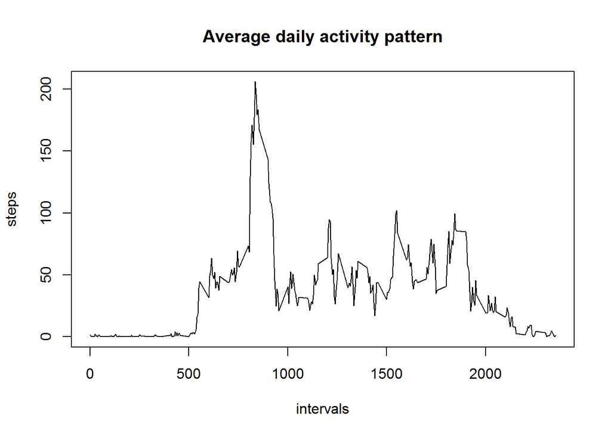

```r
avgOfSteps <- aggregate(steps ~ interval, dat, mean)

plot(avgOfSteps$interval, avgOfSteps$steps,  type = "l", ylab = "steps", xlab = "intervals", main = "Average daily activity pattern")
```

Maximum number of septs in 5-minute interval is below.

```r
max(avgOfSteps$steps)
```

```
## [1] 206.1698
```

### 4. Imputing missing values

The raw data contained some missing values. And the total number of missing values in the data set is below.

```r
sum(is.na(dat$steps))
```

```
## [1] 2304
```

Creating a new dataset that is equal to the original dataset and filling in all of the missing values in the dataset. Missing values were filed with zero.

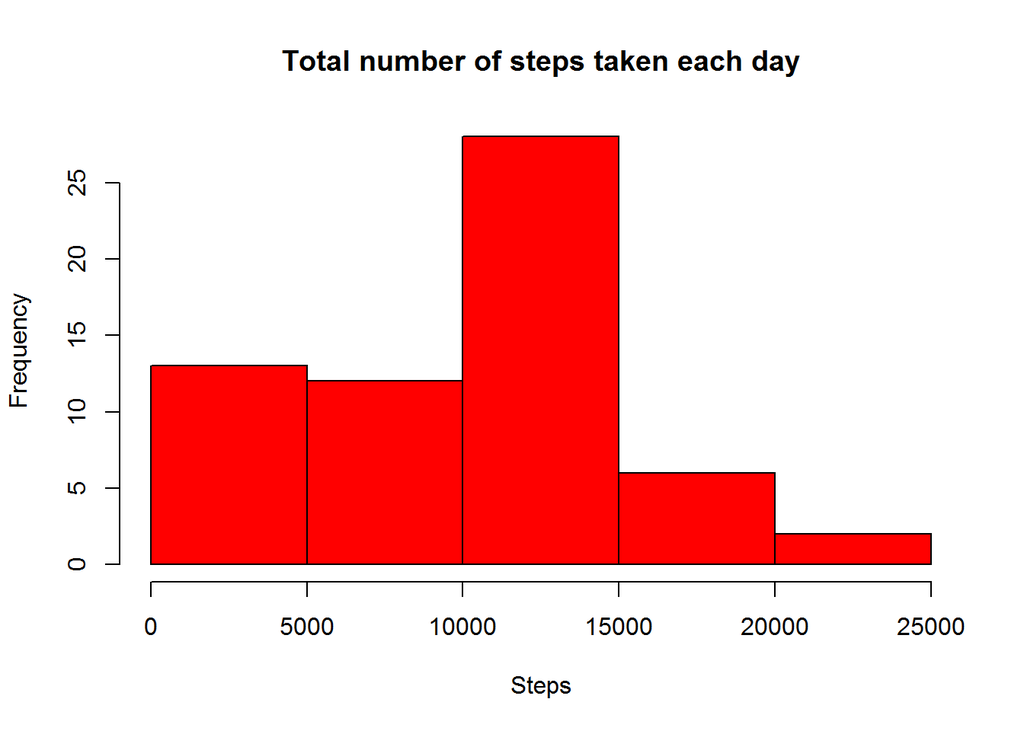

```r
newDat <- dat
newDat$steps[is.na(newDat$steps)] <- 0

sumOfNewSteps <- aggregate(steps ~ date, newDat, sum)
hist(sumOfNewSteps$steps, main = "Total number of steps taken each day", xlab = "Steps", col="red")
```

Mean of corrected data is below.

```r
mean(newDat$steps, na.rm = TRUE)
```

```
## [1] 32.47996
```

Median of corrected data is below.

```r
median(newDat$steps, na.rm = TRUE)
```

```
## [1] 0
```

### 5. Are there differences in activity patterns between weekdays and weekends?

Creating a new factor variable in the dataset with two levels – “weekday” and “weekend” indicating whether a given date is a weekday or weekend day.

```r
newDat$dateType <- weekdays(as.Date(newDat$date))

getWeekdayType <- function(date) {
    ifelse (date == "토요일" | date == "일요일", "weekend", "weekday" )
}

newDat$weekdayType <- sapply(newDat$dateType, getWeekdayType)
```

And making a panel plot containing a time series plot of the 5-minute interval and the average number of steps taken, averaged across all weekday days or weekend days.

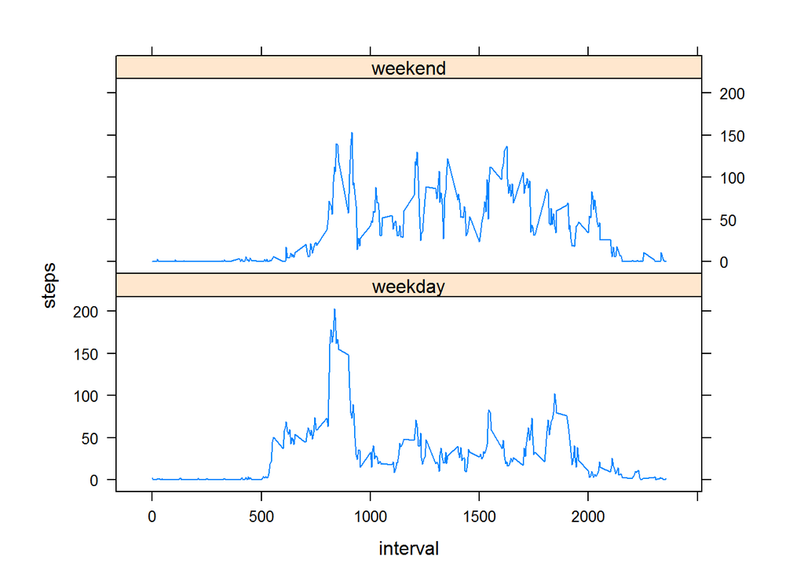

```r
library(lattice)
weekDat <- aggregate(steps ~ interval + weekdayType, newDat, mean)
xyplot(steps ~ interval | factor(weekdayType), data=weekDat, aspect=1/3, type="l")
```

There are more steps on weekend than weekday.